# Boston Housing Data

## Regression Tree

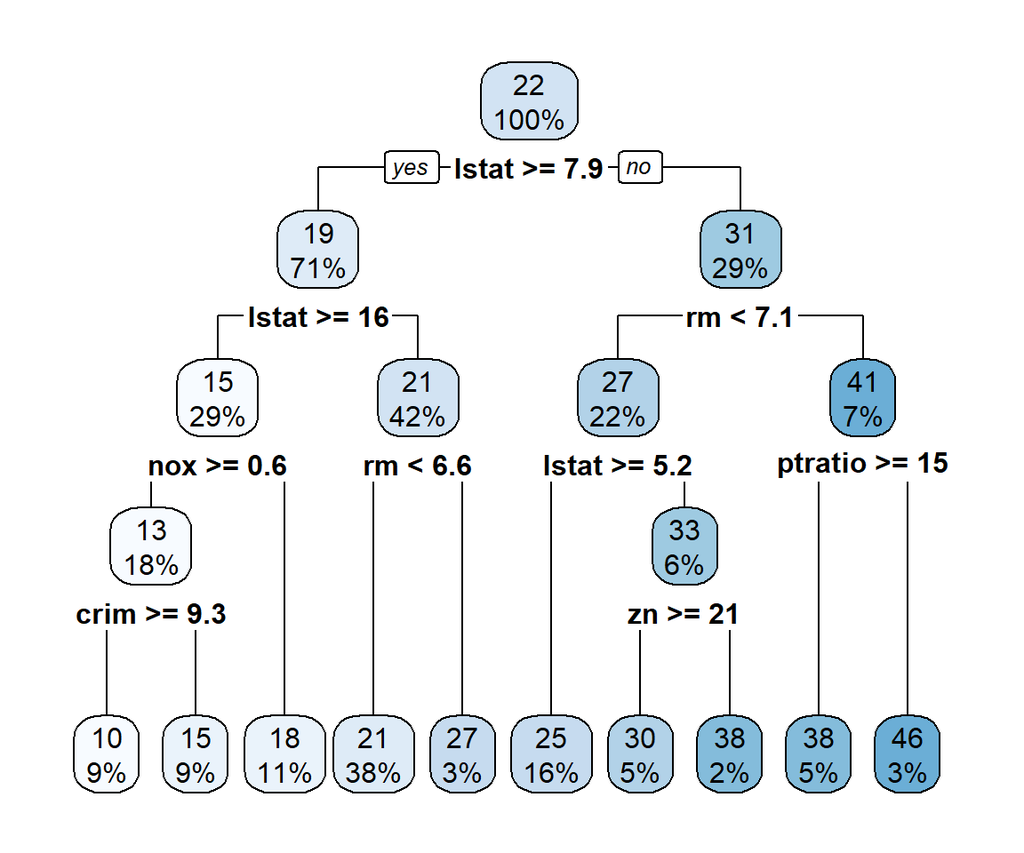

Performance:

```
## Train MSE of tree:  15.44621
```

```
##
##  Test MSE of tree:  25.57671
```

## GAMs

A generalized additive model (GAM) is a generalized linear model in which the linear predictor depends linearly on unknown smooth functions of some predictor variables, and interest focuses on inference about these smooth functions. These are called splines.

```
##
## Family: gaussian
## Link function: identity
##
## Formula:
## medv ~ s(crim) + s(zn) + s(indus) + s(nox) + s(rm) + s(age) +
##     s(dis) + s(tax) + s(ptratio) + s(black) + s(lstat)
##
## Parametric coefficients:
##             Estimate Std. Error t value Pr(>|t|)
## (Intercept)  22.1494     0.1677   132.1   <2e-16 ***
## ---
## Signif. codes:  0 '***' 0.001 '**' 0.01 '*' 0.05 '.' 0.1 ' ' 1
##
## Approximate significance of smooth terms:
##              edf Ref.df      F  p-value
## s(crim)    2.203  2.752 23.085 5.30e-11 ***
## s(zn)      1.000  1.000  0.012   0.9119
## s(indus)   2.953  3.646  2.720   0.0442 *
## s(nox)     8.666  8.945 11.897  < 2e-16 ***
## s(rm)      7.661  8.525 14.399  < 2e-16 ***
## s(age)     1.000  1.000  0.299   0.5850
## s(dis)     8.592  8.942  5.262 1.16e-06 ***
## s(tax)     6.850  7.808  6.220 3.81e-07 ***
## s(ptratio) 1.722  2.154 22.557 3.04e-10 ***
## s(black)   1.192  1.354  2.168   0.1787
## s(lstat)   5.951  7.148 24.518  < 2e-16 ***
## ---
## Signif. codes:  0 '***' 0.001 '**' 0.01 '*' 0.05 '.' 0.1 ' ' 1
##
## R-sq.(adj) =  0.863   Deviance explained = 88.1%
## GCV = 11.548  Scale est. = 9.9567    n = 354
```

Plot of GAM:

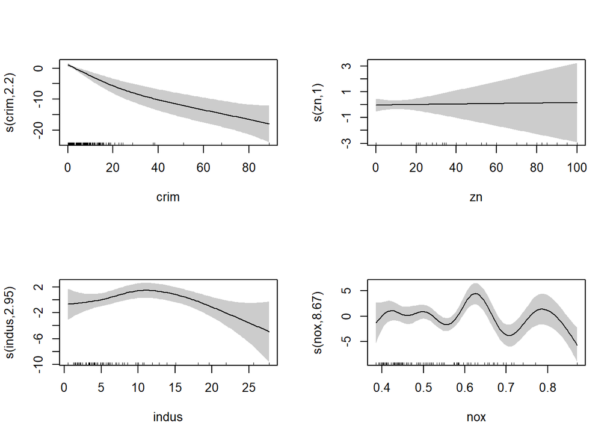

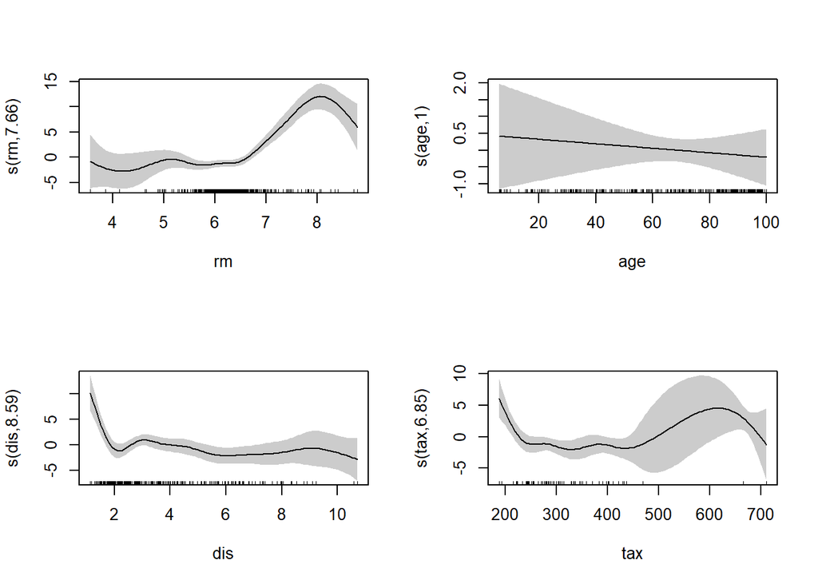

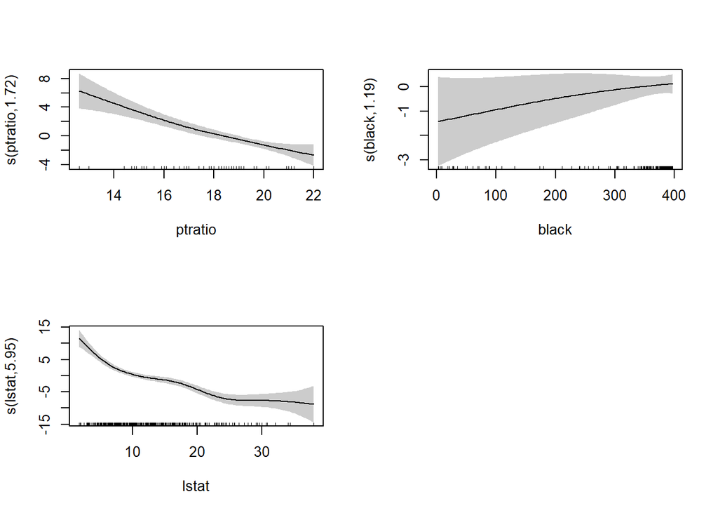

```
## Train MSE for GAM:  8.584398
```

```
##
## Test MSE for GAM:  12.74174
```

## Neural Networks

For regression problems add lineout = TRUE when training model. In addition, the response needs to be standardized to [0,1] [0,1] interval. It’s important normalize the response. If not, most of the times the algorithm will not converge. I chose to use the min-max method and scale the data in the interval [0,1].

```r
maxs <- apply(Boston, 2, max)
mins <- apply(Boston, 2, min)

scaled <- as.data.frame(scale(Boston, center = mins, scale = maxs - mins))
index <- sample(1:nrow(Boston),round(0.75*nrow(Boston)))

train_ <- scaled[index,]
test_ <- scaled[-index,]

n <- names(train_)
f <- as.formula(paste("medv ~", paste(n[!n %in% "medv"], collapse = " + ")))
nn <- neuralnet(f,data=train_,hidden=c(5,3),linear.output=T)
```

Visualization of the network:

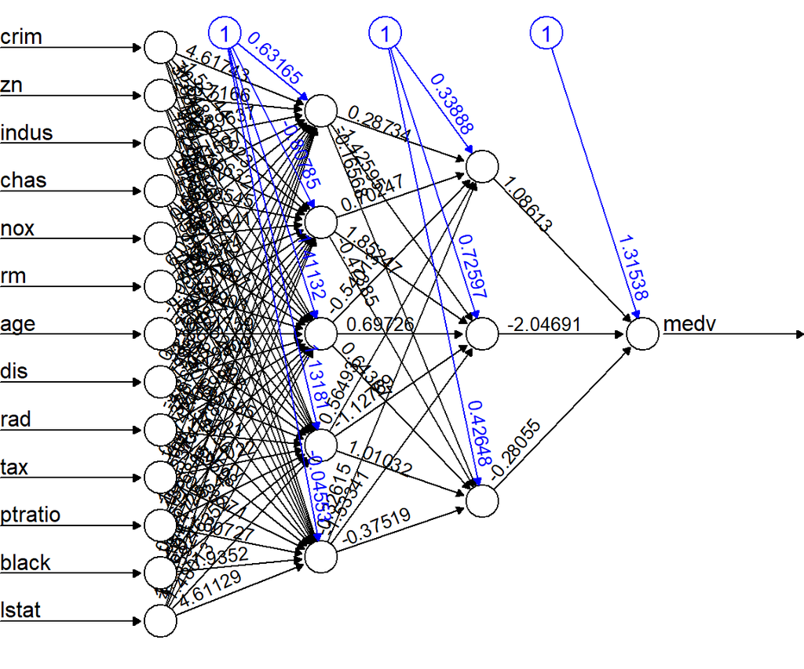

Predictions:

```r
pred_test <- compute(nn,test_[,1:13])
pred_train <- compute(nn,train_[,1:13])

pred_test <- pred_test$net.result*(max(Boston$medv)-min(Boston$medv))+min(Boston$medv)
pred_train <- pred_train$net.result*(max(Boston$medv)-min(Boston$medv))+min(Boston$medv)

test.r <- (test_$medv)*(max(Boston$medv)-min(Boston$medv))+min(Boston$medv)
train.r <- (train_$medv)*(max(Boston$medv)-min(Boston$medv))+min(Boston$medv)

# MSE of testing set
test_mse_nn <- sum((test.r - pred_test)^2)/nrow(test_)
train_mse_nn <- sum((train.r - pred_train)^2)/nrow(train_)
cat("Test MSE of NN: ", test_mse_nn)
```

```
## Test MSE of NN:  12.73724
```

```r
cat("\nTrain MSE of NN: ", train_mse_nn)
```

```
##
## Train MSE of NN:  4.582232
```